# Project Practical Machine Learning Project

Luis Fernando Perez Armas

## Summary

Using devices such as Jawbone Up, Nike FuelBand, and Fitbit it is now possible to collect a large amount of data about personal activity relatively inexpensively. These type of devices are part of the quantified self movement – a group of enthusiasts who take measurements about themselves regularly to improve their health, to find patterns in their behavior, or because they are tech geeks. One thing that people regularly do is quantify how much of a particular activity they do, but they rarely quantify how well they do it. In this project, your goal will be to use data from accelerometers on the belt, forearm, arm, and dumbell of 6 participants. They were asked to perform barbell lifts correctly and incorrectly in 5 different ways. More information is available from the website here: http://groupware.les.inf.puc-rio.br/har (see the section on the Weight Lifting Exercise Dataset).

The goal of the following project is to predict the manner in which test subjects performed the exercise. This is the “classe” variable in the training set.

he training data for this project are available here:

https://d396qusza40orc.cloudfront.net/predmachlearn/pml-training.csv

The test data are available here:

https://d396qusza40orc.cloudfront.net/predmachlearn/pml-testing.csv

The data for this project come from this source: http://groupware.les.inf.puc-rio.br/har. If you use the document you create for this class for any purpose please cite them as they have been very generous in allowing their data to be used for this kind of assignment.

## Part 1: Setting up R

```r
library(caret)
library(dplyr)
library(Hmisc)
```

```r
library(corrplot)
library(ggplot2)
library(lattice)
library(rattle)
library(data.table)
library(kernlab)
```

## Part 2: Getting the data

```r
training_original<-read.csv("training.csv", na.strings = c("NA",""))
testing_original<-read.csv("testing.csv", na.strings = c("NA",""))

dim(training_original);dim(testing_original)
```

```
## [1] 19622   160
```

```
## [1]  20 160
```

```r
str(training_original)
```

```
## 'data.frame':    19622 obs. of  160 variables:
##  $ X                       : int  1 2 3 4 5 6 7 8 9 10 ...
##  $ user_name               : Factor w/ 6 levels "adelmo","carlitos",..: 2 2 2 2 2 2 2 2 2 2 ...
##  $ raw_timestamp_part_1    : int  1323084231 1323084231 1323084231 1323084232 1323084232 1323084232 1323084232 1323084232 1323084232 1323084232 ...
##  $ raw_timestamp_part_2    : int  788290 808298 820366 120339 196328 304277 368296 440390 484323 484434 ...
##  $ cvtd_timestamp          : Factor w/ 20 levels "02/12/2011 13:32",..: 9 9 9 9 9 9 9 9 9 9 ...
##  $ new_window              : Factor w/ 2 levels "no","yes": 1 1 1 1 1 1 1 1 1 1 ...
##  $ num_window              : int  11 11 11 12 12 12 12 12 12 12 ...
##  $ roll_belt               : num  1.41 1.41 1.42 1.48 1.48 1.45 1.42 1.42 1.43 1.45 ...
##  $ pitch_belt              : num  8.07 8.07 8.07 8.05 8.07 8.06 8.09 8.13 8.16 8.17 ...
##  $ yaw_belt                : num  -94.4 -94.4 -94.4 -94.4 -94.4 -94.4 -94.4 -94.4 -94.4 -94.4 ...
##  $ total_accel_belt        : int  3 3 3 3 3 3 3 3 3 3 ...
##  $ kurtosis_roll_belt      : Factor w/ 396 levels "-0.016850","-0.021024",..: NA NA NA NA NA NA NA NA NA NA ...
##  $ kurtosis_picth_belt     : Factor w/ 316 levels "-0.021887","-0.060755",..: NA NA NA NA NA NA NA NA NA NA ...
##  $ kurtosis_yaw_belt       : Factor w/ 1 level "#DIV/0!": NA NA NA NA NA NA NA NA NA NA ...
```

[output cut: 86 more lines]

## Part3: Cleaning data

### removing NA’s

there are multuple variables on the data set that are mostly NA values, they are not going to be considered as part of the model and therefore they need to be removed from the dataset

```r
nodata <- colSums(is.na(training_original)) > 0

training1<-training_original[,!nodata]

dim(training1)
```

```
## [1] 19622    60
```

### Looking for variables with no variation

to look for variables with no variation the function nearzerovar will be used

```r
near0var<-nearZeroVar(training1,saveMetrics = TRUE)

training2<-training1[,!near0var$nzv]

near0var
```

```
##                      freqRatio percentUnique zeroVar   nzv
## X                     1.000000  100.00000000   FALSE FALSE
## user_name             1.100679    0.03057792   FALSE FALSE
## raw_timestamp_part_1  1.000000    4.26562022   FALSE FALSE
## raw_timestamp_part_2  1.000000   85.53154622   FALSE FALSE
## cvtd_timestamp        1.000668    0.10192641   FALSE FALSE
## new_window           47.330049    0.01019264   FALSE  TRUE
## num_window            1.000000    4.37264295   FALSE FALSE
## roll_belt             1.101904    6.77810621   FALSE FALSE
## pitch_belt            1.036082    9.37722964   FALSE FALSE
## yaw_belt              1.058480    9.97349913   FALSE FALSE
## total_accel_belt      1.063160    0.14779329   FALSE FALSE
## gyros_belt_x          1.058651    0.71348486   FALSE FALSE
## gyros_belt_y          1.144000    0.35164611   FALSE FALSE
## gyros_belt_z          1.066214    0.86127816   FALSE FALSE
## accel_belt_x          1.055412    0.83579655   FALSE FALSE
## accel_belt_y          1.113725    0.72877383   FALSE FALSE
## accel_belt_z          1.078767    1.52379982   FALSE FALSE
## magnet_belt_x         1.090141    1.66649679   FALSE FALSE
## magnet_belt_y         1.099688    1.51870350   FALSE FALSE
## magnet_belt_z         1.006369    2.32901845   FALSE FALSE
## roll_arm             52.338462   13.52563449   FALSE FALSE
## pitch_arm            87.256410   15.73234125   FALSE FALSE
## yaw_arm              33.029126   14.65701763   FALSE FALSE
## total_accel_arm       1.024526    0.33635715   FALSE FALSE
## gyros_arm_x           1.015504    3.27693405   FALSE FALSE
## gyros_arm_y           1.454369    1.91621649   FALSE FALSE
## gyros_arm_z           1.110687    1.26388747   FALSE FALSE
## accel_arm_x           1.017341    3.95984099   FALSE FALSE
## accel_arm_y           1.140187    2.73672409   FALSE FALSE
## accel_arm_z           1.128000    4.03628580   FALSE FALSE
## magnet_arm_x          1.000000    6.82397309   FALSE FALSE
## magnet_arm_y          1.056818    4.44399144   FALSE FALSE
## magnet_arm_z          1.036364    6.44684538   FALSE FALSE
## roll_dumbbell         1.022388   84.20650290   FALSE FALSE
## pitch_dumbbell        2.277372   81.74498012   FALSE FALSE
## yaw_dumbbell          1.132231   83.48282540   FALSE FALSE
## total_accel_dumbbell  1.072634    0.21914178   FALSE FALSE
## gyros_dumbbell_x      1.003268    1.22821323   FALSE FALSE
## gyros_dumbbell_y      1.264957    1.41677709   FALSE FALSE
## gyros_dumbbell_z      1.060100    1.04984201   FALSE FALSE
## accel_dumbbell_x      1.018018    2.16593619   FALSE FALSE
## accel_dumbbell_y      1.053061    2.37488533   FALSE FALSE
## accel_dumbbell_z      1.133333    2.08949139   FALSE FALSE
## magnet_dumbbell_x     1.098266    5.74864948   FALSE FALSE
## magnet_dumbbell_y     1.197740    4.30129447   FALSE FALSE
## magnet_dumbbell_z     1.020833    3.44511263   FALSE FALSE
## roll_forearm         11.589286   11.08959331   FALSE FALSE
## pitch_forearm        65.983051   14.85577413   FALSE FALSE
## yaw_forearm          15.322835   10.14677403   FALSE FALSE
## total_accel_forearm   1.128928    0.35674243   FALSE FALSE
## gyros_forearm_x       1.059273    1.51870350   FALSE FALSE
## gyros_forearm_y       1.036554    3.77637346   FALSE FALSE
## gyros_forearm_z       1.122917    1.56457038   FALSE FALSE
## accel_forearm_x       1.126437    4.04647844   FALSE FALSE
## accel_forearm_y       1.059406    5.11160942   FALSE FALSE
## accel_forearm_z       1.006250    2.95586586   FALSE FALSE
## magnet_forearm_x      1.012346    7.76679238   FALSE FALSE
## magnet_forearm_y      1.246914    9.54031189   FALSE FALSE
## magnet_forearm_z      1.000000    8.57710733   FALSE FALSE
## classe                1.469581    0.02548160   FALSE FALSE
```

```r
dim(training2)
```

```
## [1] 19622    59
```

### Removing variables not related to the prediction model

The following variables are not variables that can be used for the prediction model therefore they are going to be removed from the data

X  
user_name  
raw_timestamp_part_1  
raw_timestamp_part_2  
cvtd_timestamp  
new_window  
num_window

```r
training_clean<-training2[,-c(1,2,3,4,5,6)]

dim(training_clean)
```

```
## [1] 19622    53
```

## Part4: Data Slicing

training_clean data is going to be divided in three, a training set a validation set and a testing this is going to be done with the objective of testing multiple models.

```r
intrain<-createDataPartition(y=training_clean$classe,p=0.7,list = FALSE)

training_set<-training_clean[intrain,]


intrain2<-createDataPartition(y=training_set$classe,p=0.7,list = FALSE)

#Real training set

training_training<-training_set[intrain2,]

#testing set to try various models

testing_testing<-training_set[-intrain2,]

#validation set

validation<-training_clean[-intrain,]

dim(training_training);dim(testing_testing);dim(validation)
```

```
## [1] 9619   53
```

```
## [1] 4118   53
```

```
## [1] 5885   53
```

## Part5: Model with Threes “rpart”

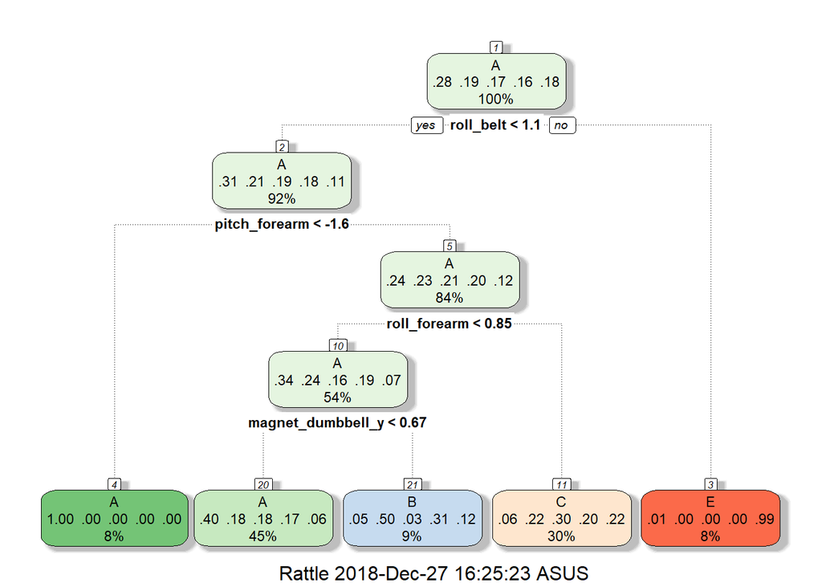

```r
modelfit1<-train(classe ~ ., data=training_training,method = "rpart",preProcess=c("center","scale"))

fancyRpartPlot(modelfit1$finalModel)
```

```r
predictions_model1<-predict(modelfit1,newdata=testing_testing)

CF1<-confusionMatrix(predictions_model1,testing_testing$classe)

CF1
```

```
## Confusion Matrix and Statistics
##
##           Reference
## Prediction    A    B    C    D    E
##          A 1065  333  351  300   96
##          B   21  193   13  116   46
##          C   83  271  354  259  265
##          D    0    0    0    0    0
##          E    2    0    0    0  350
##
## Overall Statistics
##
##                Accuracy : 0.4764
##                  95% CI : (0.4611, 0.4918)
##     No Information Rate : 0.2844
##     P-Value [Acc > NIR] : < 2.2e-16
##
##                   Kappa : 0.3163
##  Mcnemar's Test P-Value : NA
##
## Statistics by Class:
##
##                      Class: A Class: B Class: C Class: D Class: E
## Sensitivity            0.9095  0.24216  0.49304   0.0000  0.46235
## Specificity            0.6335  0.94098  0.74176   1.0000  0.99940
## Pos Pred Value         0.4965  0.49614  0.28734      NaN  0.99432
## Neg Pred Value         0.9463  0.83803  0.87387   0.8361  0.89193
## Prevalence             0.2844  0.19354  0.17436   0.1639  0.18383
## Detection Rate         0.2586  0.04687  0.08596   0.0000  0.08499
## Detection Prevalence   0.5209  0.09446  0.29917   0.0000  0.08548
## Balanced Accuracy      0.7715  0.59157  0.61740   0.5000  0.73088
```

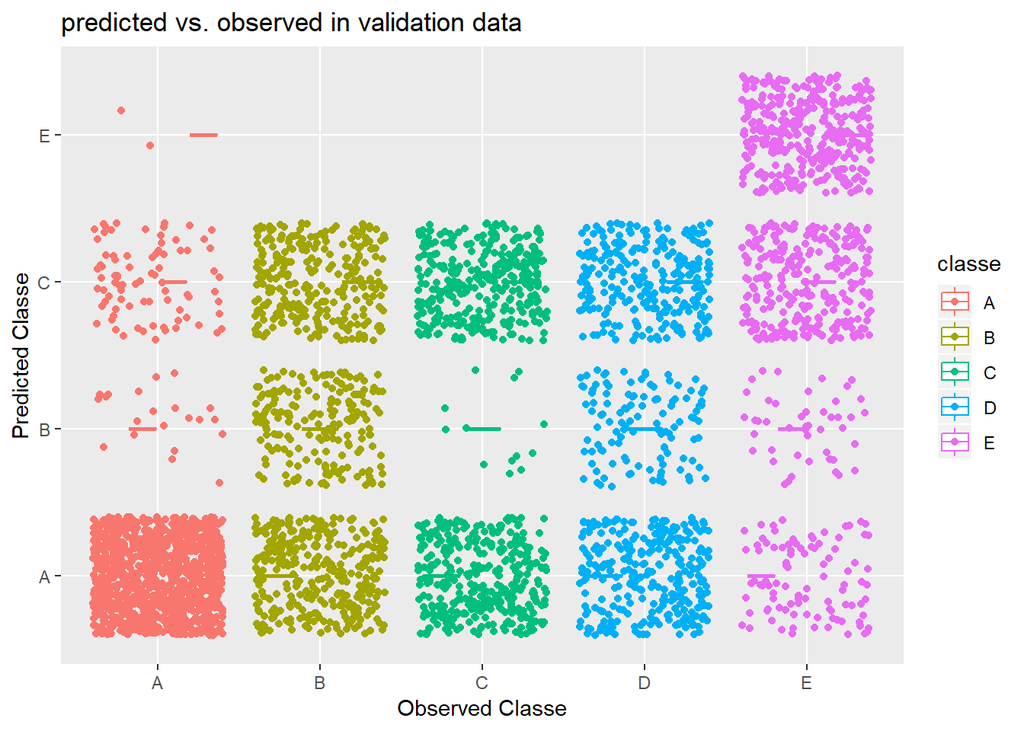

```r
impmodel1<-varImp(modelfit1)

qplot(classe, predictions_model1, data=testing_testing, colour= classe, geom = c("boxplot", "jitter"), main = "predicted vs. observed in validation data", xlab = "Observed Classe", ylab = "Predicted Classe")
```

As we can see the model have an acurracy of overall 50% which is pretty low for a good prediction model, altouhgt is better than just simple guessing it is still low, therefore we need to try with a different approach since data is quite noisy

## Part6: Model with Random forest

Due to the high computation demand required for the random forest method only three folds of cross validations are to be used and the model will be trained with only 5 threes.

```r
tc <- trainControl(method = "cv", 3)

modelfit2<-train(classe ~ ., data=training_training,method = "rf",trControl = tc,allowParallel=TRUE, importance=TRUE, ntree = 5,prox=TRUE)

modelfit2
```

```
## Random Forest
##
## 9619 samples
##   52 predictor
##    5 classes: 'A', 'B', 'C', 'D', 'E'
##
## No pre-processing
## Resampling: Cross-Validated (3 fold)
## Summary of sample sizes: 6414, 6411, 6413
## Resampling results across tuning parameters:
##
##   mtry  Accuracy   Kappa
##    2    0.9169358  0.8948506
##   27    0.9592463  0.9484342
##   52    0.9585182  0.9475042
##
## Accuracy was used to select the optimal model using the largest value.
## The final value used for the model was mtry = 27.
```

```r
predictions_model2<-predict(modelfit2,newdata=testing_testing)

CF2<-confusionMatrix(predictions_model2,testing_testing$classe)

CF2
```

```
## Confusion Matrix and Statistics
##
##           Reference
## Prediction    A    B    C    D    E
##          A 1161   14    1    0    2
##          B    6  758   17    5    5
##          C    0   23  689   21    3
##          D    1    2   10  648    4
##          E    3    0    1    1  743
##
## Overall Statistics
##
##                Accuracy : 0.9711
##                  95% CI : (0.9655, 0.976)
##     No Information Rate : 0.2844
##     P-Value [Acc > NIR] : < 2e-16
##
##                   Kappa : 0.9634
##  Mcnemar's Test P-Value : 0.03674
##
## Statistics by Class:
##
##                      Class: A Class: B Class: C Class: D Class: E
## Sensitivity            0.9915   0.9511   0.9596   0.9600   0.9815
## Specificity            0.9942   0.9901   0.9862   0.9951   0.9985
## Pos Pred Value         0.9856   0.9583   0.9361   0.9744   0.9933
## Neg Pred Value         0.9966   0.9883   0.9914   0.9922   0.9958
## Prevalence             0.2844   0.1935   0.1744   0.1639   0.1838
## Detection Rate         0.2819   0.1841   0.1673   0.1574   0.1804
## Detection Prevalence   0.2861   0.1921   0.1787   0.1615   0.1816
## Balanced Accuracy      0.9928   0.9706   0.9729   0.9775   0.9900
```

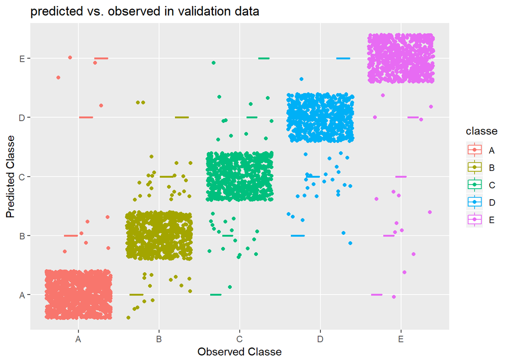

```r
impmodel2<-varImp(modelfit2)

qplot(classe, predictions_model2, data=testing_testing, colour= classe, geom = c("boxplot", "jitter"), main = "predicted vs. observed in validation data", xlab = "Observed Classe", ylab = "Predicted Classe")
```

as we can see accuracy improved tremendously in comparisson with simple threes going from ~50% to more than 97%.

## Part7: Model with GBM

```r
modelfit3<-train(classe ~ ., data=training_training,method = "gbm",trControl = tc,verbose=FALSE)
modelfit3
```

```
## Stochastic Gradient Boosting
##
## 9619 samples
##   52 predictor
##    5 classes: 'A', 'B', 'C', 'D', 'E'
##
## No pre-processing
## Resampling: Cross-Validated (3 fold)
## Summary of sample sizes: 6413, 6412, 6413
## Resampling results across tuning parameters:
##
##   interaction.depth  n.trees  Accuracy   Kappa
##   1                   50      0.7486227  0.6812495
##   1                  100      0.8109995  0.7607523
##   1                  150      0.8401082  0.7976275
##   2                   50      0.8432268  0.8013532
##   2                  100      0.9004055  0.8739563
##   2                  150      0.9254601  0.9056897
##   3                   50      0.8847078  0.8540425
##   3                  100      0.9339849  0.9164639
##   3                  150      0.9550888  0.9431755
##
## Tuning parameter 'shrinkage' was held constant at a value of 0.1
##
## Tuning parameter 'n.minobsinnode' was held constant at a value of 10
## Accuracy was used to select the optimal model using the largest value.
## The final values used for the model were n.trees = 150,
##  interaction.depth = 3, shrinkage = 0.1 and n.minobsinnode = 10.
```

```r
predictions_model3<-predict(modelfit3,newdata=testing_testing)

CF3<-confusionMatrix(predictions_model3,testing_testing$classe)
CF3
```

```
## Confusion Matrix and Statistics
##
##           Reference
## Prediction    A    B    C    D    E
##          A 1147   30    0    1    1
##          B   10  737   23    1   11
##          C    6   28  685   25    5
##          D    5    1    8  640    9
##          E    3    1    2    8  731
##
## Overall Statistics
##
##                Accuracy : 0.9568
##                  95% CI : (0.9501, 0.9628)
##     No Information Rate : 0.2844
##     P-Value [Acc > NIR] : < 2.2e-16
##
##                   Kappa : 0.9453
##  Mcnemar's Test P-Value : 2.992e-05
##
## Statistics by Class:
##
##                      Class: A Class: B Class: C Class: D Class: E
## Sensitivity            0.9795   0.9247   0.9540   0.9481   0.9657
## Specificity            0.9891   0.9864   0.9812   0.9933   0.9958
## Pos Pred Value         0.9729   0.9425   0.9146   0.9653   0.9812
## Neg Pred Value         0.9918   0.9820   0.9902   0.9899   0.9923
## Prevalence             0.2844   0.1935   0.1744   0.1639   0.1838
## Detection Rate         0.2785   0.1790   0.1663   0.1554   0.1775
## Detection Prevalence   0.2863   0.1899   0.1819   0.1610   0.1809
## Balanced Accuracy      0.9843   0.9556   0.9676   0.9707   0.9807
```

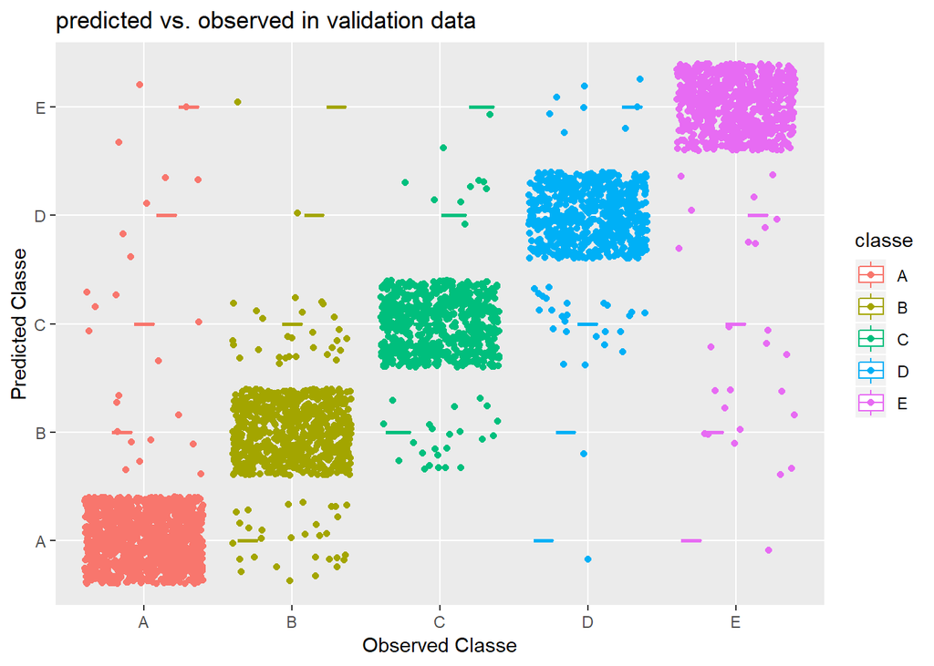

```r
qplot(classe, predictions_model3, data=testing_testing, colour= classe, geom = c("boxplot", "jitter"), main = "predicted vs. observed in validation data", xlab = "Observed Classe", ylab = "Predicted Classe")
```

In overal the best results are obtained by the random forest method therefore is the one selected to be used for the final validation process.

## Part8: Calculating predictions for the validation and original testing request

it is critical to test outbound errors for this purpose the validation set will be used to test our model

```r
predictvalidation<-predict(modelfit2,newdata=validation)
CF4<-confusionMatrix(predictvalidation,validation$classe)

CF4
```

```
## Confusion Matrix and Statistics
##
##           Reference
## Prediction    A    B    C    D    E
##          A 1657   22    1    1    1
##          B   15 1080   22    1   12
##          C    2   21  986   24    4
##          D    0    9   12  938    5
##          E    0    7    5    0 1060
##
## Overall Statistics
##
##                Accuracy : 0.9721
##                  95% CI : (0.9676, 0.9762)
##     No Information Rate : 0.2845
##     P-Value [Acc > NIR] : <2e-16
##
##                   Kappa : 0.9647
##  Mcnemar's Test P-Value : 0.0248
##
## Statistics by Class:
##
##                      Class: A Class: B Class: C Class: D Class: E
## Sensitivity            0.9898   0.9482   0.9610   0.9730   0.9797
## Specificity            0.9941   0.9895   0.9895   0.9947   0.9975
## Pos Pred Value         0.9851   0.9558   0.9508   0.9730   0.9888
## Neg Pred Value         0.9960   0.9876   0.9917   0.9947   0.9954
## Prevalence             0.2845   0.1935   0.1743   0.1638   0.1839
## Detection Rate         0.2816   0.1835   0.1675   0.1594   0.1801
## Detection Prevalence   0.2858   0.1920   0.1762   0.1638   0.1822
## Balanced Accuracy      0.9920   0.9688   0.9753   0.9839   0.9886
```

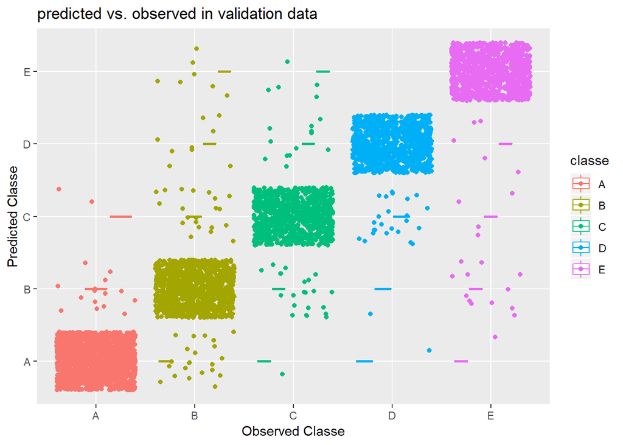

```r
qplot(classe, predictvalidation, data=validation, colour= classe, geom = c("boxplot", "jitter"), main = "predicted vs. observed in validation data", xlab = "Observed Classe", ylab = "Predicted Classe")
```

```r
predict_testing_original<-predict(modelfit2,testing_original)
predict_testing_original
```

```
##  [1] B A B A A E D B A A B C B A E E A B B B
## Levels: A B C D E
```

```r
table(predict_testing_original)
```

```
## predict_testing_original
## A B C D E
## 7 8 1 1 3
```

# Conclusions

```r
accuracy<-c(as.numeric(CF1$overall[1]),as.numeric(CF2$overall[1]),as.numeric(CF3$overall[1]))
method<-c("Tree","Random Forest","gbm")
method<-as.data.frame(method)
accuracy<-as.data.frame(accuracy)
results<-cbind(method,accuracy)

results
```

```
##          method  accuracy
## 1          Tree 0.4764449
## 2 Random Forest 0.9711025
## 3           gbm 0.9567751
```

The final model to be used is modelfit2 using the random forest algorithm with an overal accuracy of 97%